# Data Challenge Winner

Samuel Gonzalez

April 5, 2017

# Motivation

- The World Happiness Report for 2017 was recently released on World Happiness Day (Mar 20)
- The US dropped to #14 since 2016
- So, just what kind of countries make up our dataset? Are they happy or unhappy?

# Data

- Kaggle.com provides a dataset for 2016 World Happiness data from the World Happiness Report
- The data consists measures of the level of happiness of inhabitants of 157 countries
- There are seven numeric variables:
  - Economy
  - Family
  - Health
  - Freedom
  - Trust of Government
  - Generosity
  - Dystopia Residual
    - A measure of how much a country differs from a dystopian society
- Larger values of these predictors are indicative of happier people
- The country name, and a Region were manually added to the data

# Exploration

Three different multivariate methods were used to analyze this data as a whole:

- PCA
- Kmeans Clustering
- Hierarchical Clustering

Results for each method are reported

**Let’s see what the data is telling us about these 157 countries!**

The list of countries and their regions are shown below:

|  | Country | Region |
| --- | --- | --- |
| 1 | Denmark | Western Europe |
| 2 | Switzerland | Western Europe |
| 3 | Iceland | Western Europe |
| 4 | Norway | Western Europe |
| 5 | Finland | Western Europe |
| 6 | Canada | North America |
| 7 | Netherlands | Western Europe |
| 8 | New Zealand | Australia and New Zealand |
| 9 | Australia | Australia and New Zealand |
| 10 | Sweden | Western Europe |

[output cut: 147 more lines]

# PCA

The following is a scree plot showing the variance explained by each of the principal components.

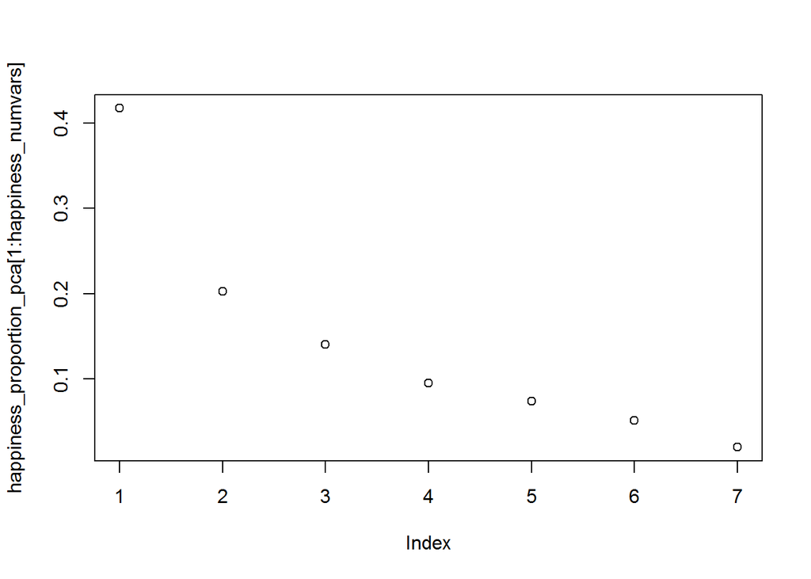

This is the story told by each Principal Component

Happiness Data Eigenvectors

|  | PC1 | PC2 | PC3 | PC4 | PC5 | PC6 | PC7 |
| --- | --- | --- | --- | --- | --- | --- | --- |
| Econ | -0.4994839 | 0.2943416 | -0.2111121 | 0.0758550 | -0.1863982 | 0.0968503 | -0.7546074 |
| Family | -0.4653272 | 0.1848541 | -0.0562424 | -0.2672843 | 0.4603361 | -0.6585061 | 0.1707510 |
| Health | -0.4841797 | 0.2592048 | -0.1849165 | -0.0811549 | -0.4198272 | 0.3285968 | 0.6110417 |
| Freedom | -0.4063178 | -0.3485127 | 0.2420538 | 0.0211520 | 0.5795885 | 0.5643345 | -0.0033220 |
| Govt_Trust | -0.3218460 | -0.4348229 | 0.1561705 | 0.7060304 | -0.2440265 | -0.3425710 | 0.0870186 |
| Giving | -0.1563188 | -0.6438609 | -0.0051629 | -0.6294594 | -0.3687829 | -0.1063930 | -0.1320658 |
| Dystopia_Res | -0.0802613 | 0.2948150 | 0.9138208 | -0.1451669 | -0.2135859 | -0.0431987 | -0.0549113 |

```
## [1] "The Total Proportion Explained by PC1 to PC3 is 0.76029141587102"
```

The biplot below shows the separations and associations between the variables. Color-coding by “Regions” help identify the regions that are closely associated with certain variables.

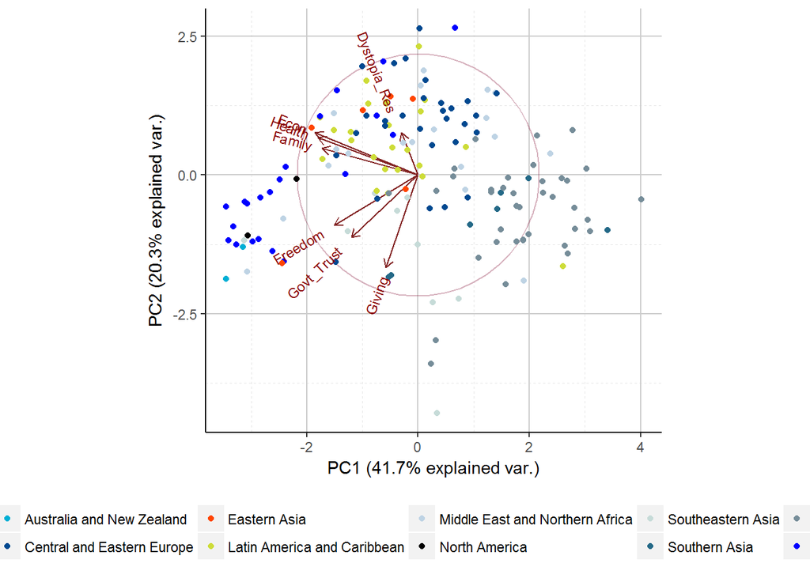

The values of PC1 and PC2 for each observation can be plotted against each other and color coded by region to visualize the distinctions that the PCA is making within the pool of countries

[interactive chart not shown]

Countries with PC1 Extremes

|  | Country | PC1 |
| --- | --- | --- |
| 8 | New Zealand | -3.45039543926556 |
| 2 | Switzerland | -3.44623908822163 |
| 1 | Denmark | -3.40956628372974 |
| 4 | Norway | -3.31526055795112 |
| 10 | Sweden | -3.26500368728648 |
| 150 | Liberia | 2.81078727995141 |
| 153 | Benin | 2.82398834999792 |
| 144 | Chad | 3.02455095206887 |
| 143 | South Sudan | 3.04575433279399 |
| 155 | Togo | 3.09005550547887 |

|  | Country | PC2 |
| --- | --- | --- |
| 119 | Myanmar | -4.29269977587685 |
| 152 | Rwanda | -3.39528841884765 |
| 97 | Somaliland Region | -2.97806833975246 |
| 102 | Laos | -2.29757424437759 |
| 140 | Cambodia | -2.23326882286332 |
| 27 | Czech Republic | 1.95035379187816 |
| 45 | Slovakia | 2.00651140036436 |
| 50 | Italy | 2.04369439310634 |
| 56 | Russia | 2.09946005684355 |
| 44 | Venezuela | 2.30677281591007 |

# Kmeans Clustering

Clustering Analysis Conducted.

The cluster means tell a different story for each cluster

[interactive chart not shown]

Stories told by Clusters

Happiness Data Kmean Cluster Means

| ClusterID | Econ | Family | Health | Freedom | Govt_Trust | Giving | Dystopia_Res |
| --- | --- | --- | --- | --- | --- | --- | --- |
| Cluster_1 | 1.1097864 | 0.9818784 | 0.9844422 | 1.1789232 | 1.4675397 | 1.0068959 | 0.0897246 |
| Cluster_2 | 0.3310766 | 0.2522108 | 0.3467381 | -0.1352700 | -0.4323883 | -0.4269380 | 0.1045598 |
| Cluster_3 | -1.2559710 | -1.0368787 | -1.2109988 | -0.4449619 | -0.0718033 | 0.1886217 | -0.2435997 |

Happiness Kmeans Cluster Characteristics

[output not shown]

Cluster Visualization 2 dimensional

[interactive chart not shown]

Cluster Visualization 3 dimensional, overlaid on Principal Components

[interactive chart not shown]

|  | Country | Kclus |
| --- | --- | --- |
| 117 | Sri Lanka | 2 |
| 79 | Indonesia | 2 |
| 96 | Vietnam | 2 |
| 85 | Kyrgyzstan | 2 |
| 65 | Turkmenistan | 2 |
| 82 | Philippines | 2 |
| 66 | Mauritius | 2 |
| 47 | Malaysia | 2 |
| 48 | Nicaragua | 2 |
| 89 | Dominican Republic | 2 |

[output cut: 74 more lines]

|  | Country | Kclus |
| --- | --- | --- |
| 119 | Myanmar | 3 |
| 152 | Rwanda | 3 |
| 97 | Somaliland Region | 3 |
| 102 | Laos | 3 |
| 140 | Cambodia | 3 |
| 76 | Somalia | 3 |
| 156 | Syria | 3 |
| 136 | Haiti | 3 |
| 122 | Kenya | 3 |
| 151 | Guinea | 3 |

[output cut: 36 more lines]

# Hierarchical Clustering

A dendogram showing membership in a cluster is shown below

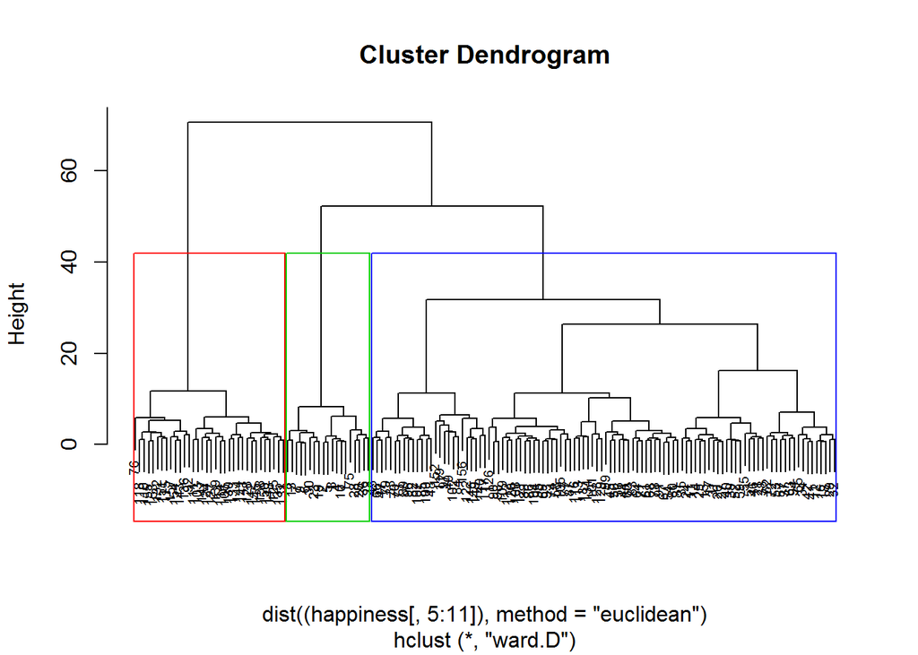

Similarly to Kmean, clusters give out different stories

[interactive chart not shown]

Happiness Hierarchical Cluster Means

|  | ClusterID | Econ | Family | Health | Freedom | Govt_Trust | Giving | Dystopia_Res |
| --- | --- | --- | --- | --- | --- | --- | --- | --- |
| Cluster_1 | Cluster_1 | 0.1874385 | 0.1987464 | 0.2518928 | -0.0046029 | -0.2441778 | -0.1732234 | -0.0308697 |
| Cluster_2 | Cluster_2 | -1.3126200 | -1.1691169 | -1.4232081 | -0.6783153 | -0.2581439 | -0.1153259 | 0.0725572 |
| Cluster_3 | Cluster_3 | 1.3229200 | 1.0042290 | 1.1680120 | 1.2390222 | 1.7984937 | 1.1545428 | 0.0391320 |

Happiness Hierarchical Cluster Characteristics

[output not shown]

|  | Country | HierCluster |
| --- | --- | --- |
| 8 | New Zealand | 3 |
| 36 | Qatar | 3 |
| 75 | Hong Kong | 3 |
| 30 | Malta | 3 |
| 23 | United Kingdom | 3 |
| 9 | Australia | 3 |
| 10 | Sweden | 3 |
| 19 | Ireland | 3 |
| 22 | Singapore | 3 |
| 1 | Denmark | 3 |

[output cut: 9 more lines]

|  | Country | HierCluster |
| --- | --- | --- |
| 119 | Myanmar | 1 |
| 152 | Rwanda | 1 |
| 97 | Somaliland Region | 1 |
| 102 | Laos | 1 |
| 140 | Cambodia | 1 |
| 156 | Syria | 1 |
| 117 | Sri Lanka | 1 |
| 84 | Bhutan | 1 |
| 49 | Uzbekistan | 1 |
| 122 | Kenya | 1 |

[output cut: 94 more lines]

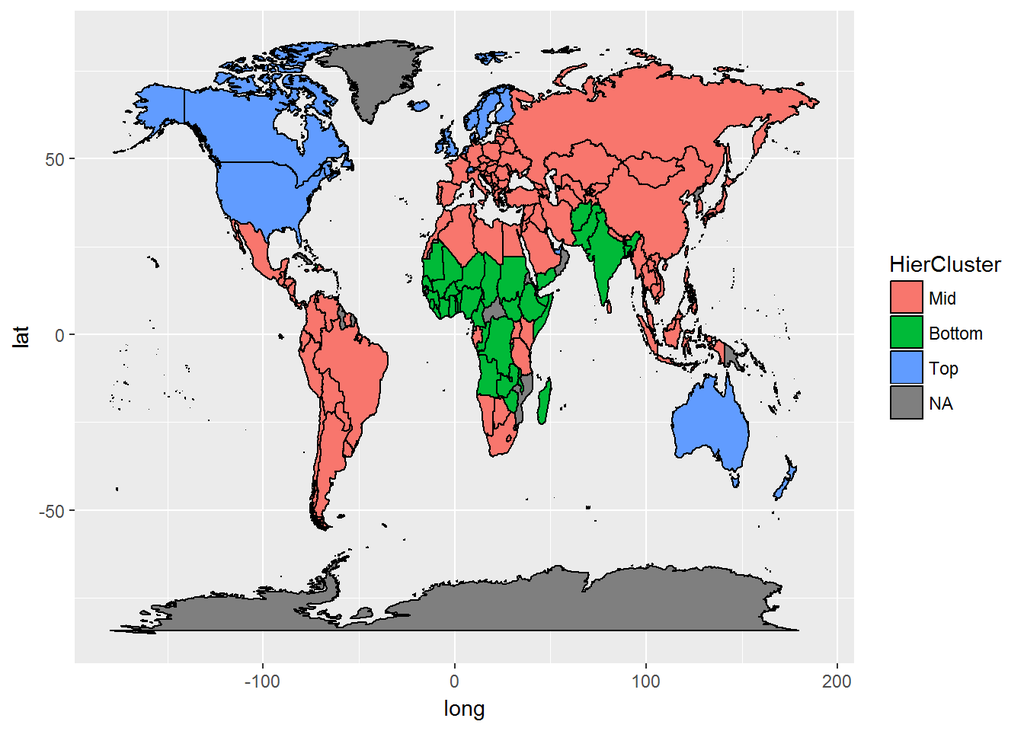